# Zillow - House value

Loading library

```r
library(tidyverse)
library(corrplot)
```

Listing all the input files

1. zillow_data_dictionary.xlsx
- Definition of columns in training datsets
2. properties_2016.csv
- all the properties with their home features for 2016. Note: Some 2017 new properties don’t have any data yet except for their parcelid’s. Those data points should be populated when properties_2017.csv is available.
3. properties_2017.csv
- all the properties with their home features for 2017 (released on 10/2/2017)
4. train_2016_v2.csv
- the training set with transactions from 1/1/2016 to 12/31/2016
5. train_2017.csv
- the training set with transactions from 1/1/2017 to 9/15/2017 (released on 10/2/2017)
6. Sample_submission.csv
- Sample submission file

```r
list.files("datasets/")
```

```
## [1] "~$zillow_data_dictionary.xlsx" "properties_2016.csv"
## [3] "properties_2017.csv"           "sample_submission.csv"
## [5] "train_2016_v2.csv"             "train_2017.csv"
## [7] "zillow_data_dictionary.xlsx"
```

# Loading the data

```r
properties_2016=read_csv("datasets/properties_2016.csv")
properties_2017=read_csv("datasets/properties_2017.csv")

train_2016_v2=read_csv("datasets/train_2016_v2.csv")

train_2017=read_csv("datasets/train_2017.csv")

sample_submission=read_csv("datasets/sample_submission.csv")
```

# Exploratory Analysis

Lets see how many unique houses in the train datasets.

```r
unique_house_train_2016=n_distinct(train_2016_v2$parcelid)
cat ("2016 train dataset has ",unique_house_train_2016," unique houses")
```

```
## 2016 train dataset has  90150  unique houses
```

```r
unique_house_train_2017=n_distinct(train_2017$parcelid)
cat ("2017 train dataset has ",unique_house_train_2017," unique houses")
```

```
## 2017 train dataset has  77414  unique houses
```

```r
c(dim(properties_2016),dim(properties_2017))
```

```
## [1] 2985217      58 2985217      58
```

```r
# To find if both the files has exactly same houses in them.
c(setdiff(properties_2016$parcelid,properties_2017$parcelid),setdiff(properties_2017$parcelid,properties_2016$parcelid))
```

```
## integer(0)
```

```r
dim(sample_submission)
```

```
## [1] 2985217       7
```

Also there are 2985217 datasets in both properties_2016 & properties_2017 . And Houses in both the datasets exactly match. Also it matches the sample_submission file.

I am interested to see how many houses were sold more than once .There were 124 out of 90150 houses that were sold more than once in 2016 (2016 training data)

```r
train_2016_v2 %>% group_by(parcelid) %>% summarise(freq=n()) %>% filter(freq>1) %>% arrange(desc(freq))
```

```
## # A tibble: 124 x 2
##    parcelid  freq
##       <int> <int>
##  1 11842707     3
##  2 10736972     2
##  3 10790468     2
##  4 10796614     2
##  5 10798910     2
##  6 10799924     2
##  7 10815854     2
##  8 10818076     2
##  9 10821829     2
## 10 10858080     2
## # ... with 114 more rows
```

```r
train_2016_v2 %>% group_by(parcelid) %>% summarise(freq=n()) %>% filter(freq>1) %>% dim()
```

```
## [1] 124   2
```

```r
train_2016_v2 %>% group_by(parcelid) %>% summarise(freq=n()) %>%  dim()
```

```
## [1] 90150     2
```

Likewise lets see for 2017 trainign data. There were 196 out of 77414 houses that were sold more than once in 2017 (2016 training data)

```r
train_2017 %>% group_by(parcelid) %>% summarise(freq=n()) %>% filter(freq>1) %>% arrange(desc(freq))
```

```
## # A tibble: 196 x 2
##    parcelid  freq
##       <int> <int>
##  1 10857130     3
##  2 11991059     3
##  3 12612211     3
##  4 10722858     2
##  5 10732347     2
##  6 10739478     2
##  7 10744507     2
##  8 10753427     2
##  9 10753829     2
## 10 10777937     2
## # ... with 186 more rows
```

```r
train_2017 %>% group_by(parcelid) %>% summarise(freq=n()) %>% filter(freq>1) %>% dim()
```

```
## [1] 196   2
```

```r
train_2017 %>% group_by(parcelid) %>% summarise(freq=n()) %>%  dim()
```

```
## [1] 77414     2
```

```r
# To find the number of houses that were sold more than once in 2016 & 2017 (as per training data)
length(which(table(c(train_2016_v2$parcelid,train_2017$parcelid))>1))
```

```
## [1] 2669
```

Above analysis shows there were 2669 houses which were sold more than once between 2016 & 2017 (again only as in trainin data time frame)

Join the train dataset with properties dataset

```r
merged_train_2016=left_join(train_2016_v2,properties_2016,by="parcelid")
merged_train_2017=left_join(train_2017,properties_2017,by="parcelid")

merged_train=rbind(merged_train_2016,merged_train_2017)
```

Summary of train data

```r
summary(merged_train)
```

```
##     parcelid            logerror        transactiondate
##  Min.   : 10711738   Min.   :-4.65542   Min.   :2016-01-01
##  1st Qu.: 11548986   1st Qu.:-0.02530   1st Qu.:2016-06-03
##  Median : 12540601   Median : 0.00600   Median :2016-10-11
##  Mean   : 12995359   Mean   : 0.01391   Mean   :2016-11-16
##  3rd Qu.: 14219303   3rd Qu.: 0.03920   3rd Qu.:2017-05-12
##  Max.   :167689317   Max.   : 5.26300   Max.   :2017-09-25
##
##  airconditioningtypeid architecturalstyletypeid  basementsqft
##  Min.   : 1.00         Length:167888            Min.   :  38.0
##  1st Qu.: 1.00         Class :character         1st Qu.: 280.0
##  Median : 1.00         Mode  :character         Median : 588.0
##  Mean   : 1.81                                  Mean   : 695.4
##  3rd Qu.: 1.00                                  3rd Qu.: 819.0
##  Max.   :13.00                                  Max.   :3560.0
##  NA's   :114100                                 NA's   :167795
##   bathroomcnt       bedroomcnt     buildingclasstypeid
##  Min.   : 0.000   Min.   : 0.000   Min.   :3.00
##  1st Qu.: 2.000   1st Qu.: 2.000   1st Qu.:4.00
##  Median : 2.000   Median : 3.000   Median :4.00
##  Mean   : 2.288   Mean   : 3.042   Mean   :3.97
##  3rd Qu.: 3.000   3rd Qu.: 4.000   3rd Qu.:4.00
##  Max.   :20.000   Max.   :16.000   Max.   :4.00
##  NA's   :34       NA's   :34       NA's   :167857
##  buildingqualitytypeid calculatedbathnbr   decktypeid
##  Min.   : 1.00         Min.   : 1.000    Min.   :66
##  1st Qu.: 4.00         1st Qu.: 2.000    1st Qu.:66
##  Median : 7.00         Median : 2.000    Median :66
##  Mean   : 6.02         Mean   : 2.312    Mean   :66
##  3rd Qu.: 7.00         3rd Qu.: 3.000    3rd Qu.:66
##  Max.   :12.00         Max.   :20.000    Max.   :66
##  NA's   :60715         NA's   :1832      NA's   :166616
##  finishedfloor1squarefeet calculatedfinishedsquarefeet
##  Min.   :  44             Min.   :    2
##  1st Qu.: 945             1st Qu.: 1183
##  Median :1252             Median : 1541
##  Mean   :1356             Mean   : 1779
##  3rd Qu.:1615             3rd Qu.: 2103
##  Max.   :7625             Max.   :35640
##  NA's   :154995           NA's   :896
```

[output cut: 97 more lines]

```
##  Min.   :2015   Min.   :      22      Min.   :    19.9
##  1st Qu.:2015   1st Qu.:   83730      1st Qu.:  2798.1
##  Median :2015   Median :  197776      Median :  4501.0
##  Mean   :2015   Mean   :  288880      Mean   :  5989.5
##  3rd Qu.:2016   3rd Qu.:  355334      3rd Qu.:  6914.2
##  Max.   :2016   Max.   :48952198      Max.   :586639.3
##  NA's   :34     NA's   :37            NA's   :45
##  taxdelinquencyflag taxdelinquencyyear censustractandblock
##  Length:167888      Min.   : 3.00      Min.   :6.037e+13
##  Class :character   1st Qu.:13.00      1st Qu.:6.037e+13
##  Mode  :character   Median :14.00      Median :6.038e+13
##                     Mean   :13.83      Mean   :6.049e+13
##                     3rd Qu.:15.00      3rd Qu.:6.059e+13
##                     Max.   :99.00      Max.   :4.830e+14
##                     NA's   :163205     NA's   :886
```

# Imouting Missing values & Correcting the datatypes

zip code is a factor variable , convert as factors . It contains 119 missing values. It needs to imputed based on lat & long coords or neighboordhoos information But for now i am goin gto impute the most common value

```r
sort(table(merged_train$regionidzip,exclude = NULL))
```

```
##
##  96034  97088  97092  96467  97111  96500  96039  96329  96002  96226
##      1      1      1      2      2      4      5      7     12     12
##  97108  96148 399675  97324  95995  97119  97331  95991  96951  95998
##     12     22     25     29     30     30     32     34     41     45
##  96323  96434  96207  96021  96986  96119  96973  96980  97316  95988
##     52     52     54     55     56     57     57     61     64     67
##  96038  96135  96136  97037  96010  96216  96322  95994  96105  97098
##     67     77     77     79     90     91     93    100    102    102
##  96037  96275  96087  96979  97059  96088  96133  96014  96126  96009
##    104    104    110    110    112    114    114    117    117    119
##   <NA>  96137  96019  96478  96956  97344  96097  96004  96048  96204
##    119    125    127    127    133    135    141    142    155    155
##  96326  95993  96371  96183  97064  96320  96201  96072  96324  96338
##    162    163    163    164    165    169    172    179    180    184
```

[output cut: 66 more lines]

```r
merged_train$regionidzip=as.factor(merged_train$regionidzip)
```

fips ia another factor variable

```r
merged_train$fips=as.factor(merged_train$fips)
```

Airconditioning ia another factor variable

```r
merged_train$airconditioningtypeid=as.factor(merged_train$airconditioningtypeid)
```

Architecture ia another factor variable

```r
merged_train$architecturalstyletypeid=as.factor(merged_train$architecturalstyletypeid)
```

decktypeid - It has only one value - Hence converting Y & N variable and convert as factor varaiable

```r
table(merged_train$decktypeid,exclude = NULL)
```

```
##
##     66   <NA>
##   1272 166616
```

```r
merged_train=merged_train %>% replace_na(list(decktypeid='N')) %>% mutate(decktypeid=as.factor(recode(decktypeid,'66'='Y')))
```

Has hot tub or spa , convert to binary numeric value

```r
merged_train=merged_train %>% replace_na(list(hashottuborspa='N')) %>% mutate(hashottuborspa=as.integer(recode(hashottuborspa,'true'=1,'N'=0)))
```

Heating system type,convert to factors

```r
merged_train=merged_train %>% replace_na(list(heatingorsystemtypeid='0')) %>% mutate(heatingorsystemtypeid=as.factor(heatingorsystemtypeid))
```

Pooltypeid10 - Spa or Hot tub Pooltypeid2 - Pool with Spa/Hot tub Pooltypeid7 - Pool without hot tub

```r
merged_train=merged_train %>% replace_na(list(pooltypeid10=0)) %>% mutate(pooltypeid10=as.integer(pooltypeid10))

merged_train=merged_train %>% replace_na(list(pooltypeid2=0)) %>% mutate(pooltypeid2=as.integer(pooltypeid2))

merged_train=merged_train %>% replace_na(list(pooltypeid7=0)) %>% mutate(pooltypeid7=as.integer(pooltypeid7))
```

propertycountylandusecode, replace it with most common value (0100) and convert into factor

```r
merged_train=merged_train %>% replace_na(list(propertycountylandusecode=0100)) %>% mutate(propertycountylandusecode=as.factor(propertycountylandusecode))
```

propertylandusetypeid, replace it with most common value (261) and convert into factor

```r
merged_train=merged_train %>% replace_na(list(propertylandusetypeid='261')) %>% mutate(propertylandusetypeid=as.factor(propertylandusetypeid))
```

Removing below variables based on my gut feeling , but eventually needs to be evaluated.

```r
merged_train=merged_train %>% select(-c(propertyzoningdesc,rawcensustractandblock,censustractandblock,regionidcity,yardbuildingsqft17,yardbuildingsqft26))
```

regionidneighborhood

```r
merged_train=merged_train %>% replace_na(list(regionidneighborhood='0')) %>% mutate(regionidneighborhood=as.factor(regionidneighborhood))
```

storytypeid - contains only one value, hence numeric flag column

```r
merged_train=merged_train %>% replace_na(list(storytypeid='NA')) %>% mutate(storytypeid=as.integer(recode(as.character(storytypeid),"0"="1","NA"="0")))
```

yearbuilt - impute with median value

```r
merged_train=merged_train %>% replace_na(list(yearbuilt=1970))
```

typeconstructiontypeid - Convert to factor

```r
merged_train=merged_train %>% replace_na(list(typeconstructiontypeid='0')) %>% mutate(typeconstructiontypeid=as.factor(typeconstructiontypeid))
```

```r
merged_train=merged_train %>% replace_na(list(structuretaxvaluedollarcnt=134100))
```

landtaxvaluedollarcnt - impute with median value

```r
merged_train=merged_train %>% replace_na(list(landtaxvaluedollarcnt=197800))
```

taxamount - impute with median value

```r
merged_train=merged_train %>% replace_na(list(taxamount=4501.0))
```

assessmentyear - impute with median value

```r
merged_train=merged_train %>% replace_na(list(assessmentyear=2015))
```

taxdelinquencyflag - Convert into binary numeric flag

```r
merged_train=merged_train %>% replace_na(list(taxdelinquencyflag='N')) %>%
  mutate(taxdelinquencyflag=recode(taxdelinquencyflag,'Y'=1,'N'=0))
```

taxdelinquencyyear - Convert to factor

```r
merged_train=merged_train %>% replace_na(list(taxdelinquencyyear=0)) %>%
  mutate(taxdelinquencyyear=as.factor(taxdelinquencyyear))
```

Poolcnt - looks like NA might be zero (i.e they don’t have pool )

```r
merged_train=merged_train %>% replace_na(list(poolcnt=0))
```

numberofstories - Replace NA with zero as other might not have any stories.

```r
table(merged_train$numberofstories,exclude = NULL)
```

```
##
##      1      2      3      4      6   <NA>
##  22413  14808    945      2      1 129719
```

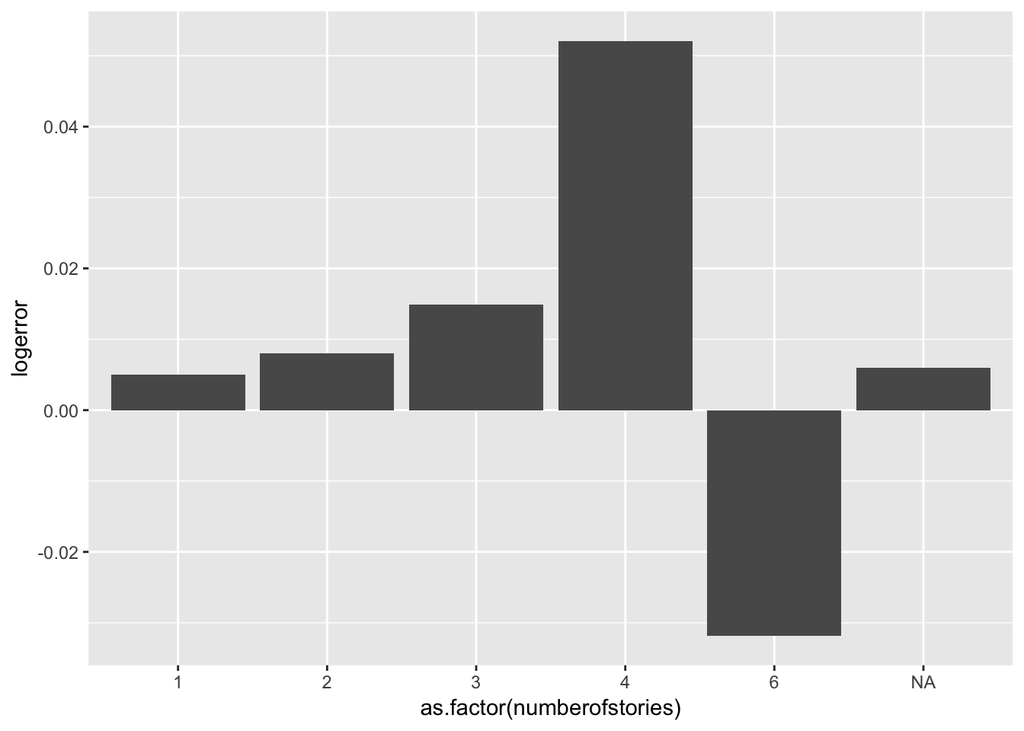

```r
merged_train %>% ggplot(aes(x=as.factor(numberofstories),y=logerror))+geom_bar(stat="summary",fun.y="median")
```

```r
merged_train=merged_train %>% replace_na(list(numberofstories=0))
```

airconditioningtypeid

```r
table(merged_train$airconditioningtypeid,exclude = NULL)
```

```
##
##      1      3      5      9     11     13   <NA>
##  49854      1    382     27    116   3408 114100
```

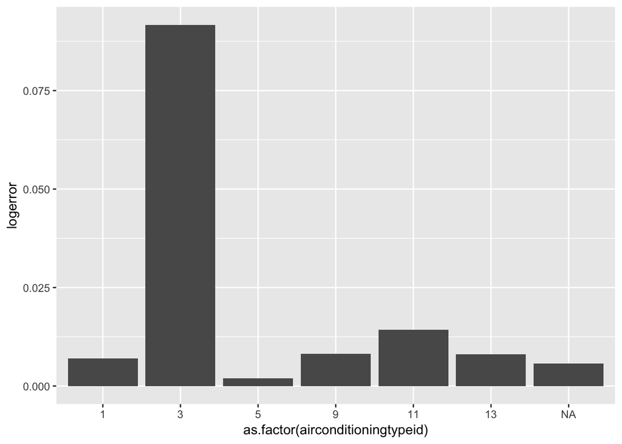

```r
merged_train %>% ggplot(aes(x=as.factor(airconditioningtypeid),y=logerror))+geom_bar(stat="summary",fun.y="median")
```

```r
merged_train=merged_train %>% mutate(airconditioningtypeid=as.numeric(airconditioningtypeid)) %>% replace_na(list(airconditioningtypeid='0')) %>% mutate(airconditioningtypeid=as.factor(airconditioningtypeid))
```

# Finding correlation

Extract only numeric features Find the correlation within the variables Eliminate the duplicate variables by seeing high correlation between them

```r
numeric_features=colnames(merged_train[,which(sapply(merged_train,class) %in% c("numeric","integer"))])
#numeric_features

cor_numeric_features=cor(merged_train[,numeric_features],use='pairwise.complete.obs')
```

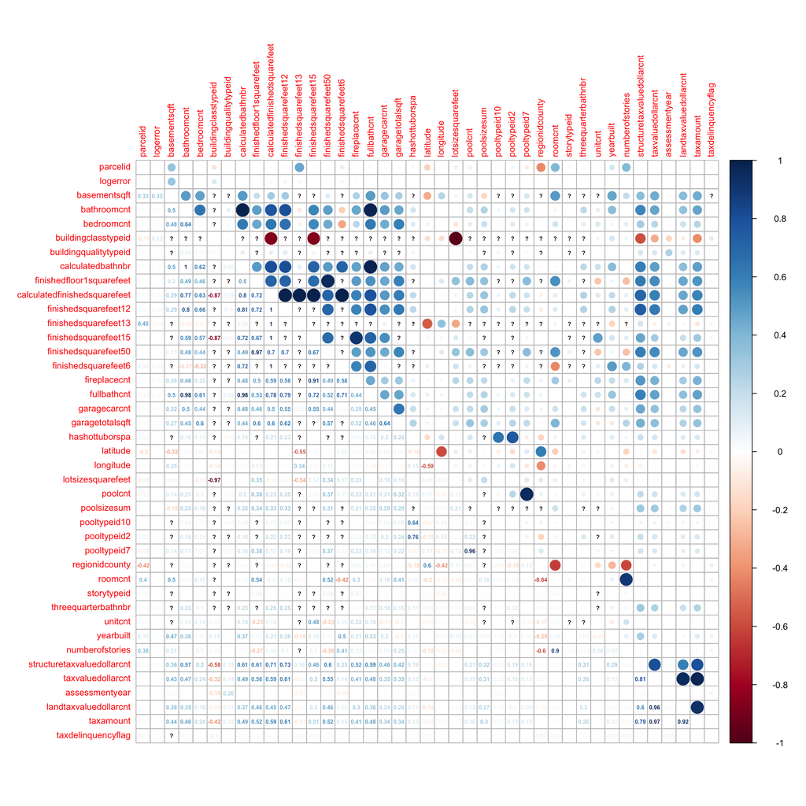

```r
corrplot.mixed(cor_numeric_features,tl.cex = 0.8,tl.pos="lt",upper = "circle",number.cex=0.5)
```

From the above correlation plot ,below group of variables are highly correlated

calculatedfinishedsquarefeet , finishedfloor1squarefeet , finishedsquarefeet12 , finishedsquarefeet13 , finishedsquarefeet15 , finishedsquarefeet50, finishedsquarefeet6

Lets keep only the feature with minimun missing values. As per the below results only keep calculatedfinishedsquarefeet

```r
sort(colSums(is.na(merged_train[,c("calculatedfinishedsquarefeet" , "finishedfloor1squarefeet" , "finishedsquarefeet12" , "finishedsquarefeet13" , "finishedsquarefeet15" , "finishedsquarefeet50", "finishedsquarefeet6")])),decreasing = T)
```

```
##         finishedsquarefeet13          finishedsquarefeet6
##                       167813                       167081
##         finishedsquarefeet15     finishedfloor1squarefeet
##                       161297                       154995
##         finishedsquarefeet50         finishedsquarefeet12
##                       154995                         8369
## calculatedfinishedsquarefeet
##                          896
```

```r
merged_train=merged_train %>% select(-c(finishedsquarefeet13,finishedsquarefeet6,finishedsquarefeet15,finishedfloor1squarefeet,finishedsquarefeet50,finishedsquarefeet12))
```

bathroomcnt is highly correlated with calculatedbathnbr,fullbathcnt and as per the below results calculatedbathnbr & fullbathcnt has more missing value, hence removing it.

```r
sort(colSums(is.na(merged_train[,c("calculatedbathnbr","bathroomcnt","fullbathcnt")])),decreasing = T)
```

```
## calculatedbathnbr       fullbathcnt       bathroomcnt
##              1832              1832                34
```

```r
merged_train=merged_train %>% select(-c(calculatedbathnbr,fullbathcnt))
```

landtaxvaluedollorcnt & taxamount is highly correlated . Going to keep taxamount

```r
cor(data.frame(landtaxvaluedollarcnt=merged_train$landtaxvaluedollarcnt,
                  taxamount=merged_train$taxamount,
                  logerror=merged_train$logerror))
```

```
##                       landtaxvaluedollarcnt    taxamount      logerror
## landtaxvaluedollarcnt          1.0000000000  0.923754787 -0.0007205407
## taxamount                      0.9237547872  1.000000000 -0.0021615076
## logerror                      -0.0007205407 -0.002161508  1.0000000000
```

```r
merged_train=merged_train %>% select(-landtaxvaluedollarcnt)
```

# Missing data

```r
sort(colSums(is.na(merged_train)),decreasing = T)
```

```
##          buildingclasstypeid                 basementsqft
##                       167857                       167795
##                fireplaceflag     architecturalstyletypeid
##                       167494                       167420
##                  poolsizesum                 fireplacecnt
##                       166050                       149992
##          threequarterbathnbr                 garagecarcnt
##                       145773                       112431
##              garagetotalsqft        buildingqualitytypeid
##                       112431                        60715
##                      unitcnt            lotsizesquarefeet
##                        58832                        18442
## calculatedfinishedsquarefeet                  regionidzip
##                          896                          119
##            taxvaluedollarcnt                  bathroomcnt
##                           36                           34
##                   bedroomcnt                         fips
##                           34                           34
##                     latitude                    longitude
##                           34                           34
##               regionidcounty                      roomcnt
##                           34                           34
##                     parcelid                     logerror
##                            0                            0
##              transactiondate        airconditioningtypeid
##                            0                            0
##                   decktypeid               hashottuborspa
##                            0                            0
##        heatingorsystemtypeid                      poolcnt
##                            0                            0
##                 pooltypeid10                  pooltypeid2
##                            0                            0
##                  pooltypeid7    propertycountylandusecode
##                            0                            0
##        propertylandusetypeid         regionidneighborhood
##                            0                            0
##                  storytypeid       typeconstructiontypeid
##                            0                            0
##                    yearbuilt              numberofstories
##                            0                            0
##   structuretaxvaluedollarcnt               assessmentyear
##                            0                            0
##                    taxamount           taxdelinquencyflag
##                            0                            0
##           taxdelinquencyyear
##                            0
```

Buildingclasstypeid , since it has 30 observations with ‘4’ & 1 observation with ‘3’ value. Since not lot of variation in this feature , i am going to remove

```r
table(merged_train$buildingclasstypeid,exclude = NULL)
```

```
##
##      3      4   <NA>
##      1     30 167857
```

```r
merged_train=merged_train %>% select(-buildingclasstypeid)
```

basementsqft , most of the values are missing , hence removiign from the dataset

```r
table(merged_train$basementsqft,exclude = NULL)
```

```
##
##     38     90    100    112    126    162    168    184    196    198
##      1      1      3      1      1      1      2      1      1      1
##    200    204    224    234    238    252    254    260    273    280
##      1      1      1      1      1      1      1      1      2      1
##    300    312    314    330    352    380    384    394    396    405
##      1      1      1      1      1      1      1      1      1      1
##    485    493    510    512    515    540    557    564    579    585
##      1      1      1      1      3      1      1      1      1      1
##    588    600    604    608    616    640    645    669    671    674
##      1      1      1      1      1      2      1      1      1      1
##    676    690    700    760    771    786    800    802    814    819
##      1      1      4      1      1      1      1      1      1      1
##    831    900    912    913   1048   1210   1218   1252   1312   1350
##      1      2      2      1      1      1      1      1      2      1
##   1416   1528   1551   1555   1809   1969   3112   3560   <NA>
##      1      3      1      1      1      1      1      1 167795
```

```r
merged_train=merged_train %>% select(-basementsqft)
```

Also below features has lot of missing values , hence removing it fireplaceflag,architecturalstyletypeid,poolsizesum,fireplacecnt,threequarterbathnbr

```r
merged_train=merged_train %>% select(-c(fireplaceflag,architecturalstyletypeid,poolsizesum,fireplacecnt,threequarterbathnbr))
```